# 코스모스 — 우주적 겸손의 연습

Culture Voyager #7 | 인생을 바꾸는 책

Author

Nakcho Choi

Published

May 23, 2026

← Culture Voyager 목차로 돌아가기

## 0.07 픽셀

1990년 2월 14일. 밸런타인데이.

보이저 1호가 지구에서 60억 킬로미터 떨어진 곳에서 뒤를 돌아봤다. 카메라 셔터가 열리고, 0.12초 동안 빛을 모았다. 결과물은 640 × 480 해상도의 사진 한 장. 그 안에서 지구는 0.12 픽셀, 넉넉하게 잡아도 0.07 픽셀에 불과했다. 태양 빛이 산란되며 만든 줄무늬 위에 걸린, 창백한 푸른 점 하나.

이 사진을 보고 칼 세이건은 이렇게 말했다.

> *“저 점을 다시 보세요. 저기가 여기입니다. 저것이 우리의 고향입니다. 저것이 우리입니다.”*

그리고 그는 한 권의 책을 쓰기 시작했다. 아니, 정확하게는 그보다 10년 전에 쓴 책이 있었다. 1980년, TV 다큐멘터리 시리즈와 함께 세상에 나온 《코스모스》. 출간 이후 70주 동안 뉴욕타임스 베스트셀러 목록에 올라 있었고, 지금까지 세계에서 가장 많이 팔린 과학 서적으로 남아 있다.

40년이 넘은 책을 왜 지금 꺼내드냐고? 솔직히, 이 책이 틀린 부분이 꽤 많기 때문이다. 명왕성은 더 이상 행성이 아니고, 외계 생명에 대한 낙관적 추정도 수정이 필요하다. 하지만 이 책이 던지는 질문 — “우리는 누구인가, 어디서 왔는가, 어디로 가는가” — 이것은 전혀 낡지 않았다.

## 브루클린의 별 보는 소년

1934년, 뉴욕 브루클린. 재단사 아버지와 가정주부 어머니 사이에서 태어난 유대계 소년이 있었다. 부모님은 과학자가 아니었고, 집에 망원경 같은 건 없었다. 하지만 이 소년에게는 한 가지 특별한 경험이 있었다 — 1939년 뉴욕 만국박람회.

다섯 살의 칼 세이건은 그곳에서 ’미래의 도시’를 봤다. 미래가 실체로 느껴진 최초의 순간. 훗날 그는 이렇게 회상했다. “그때 나는 과학이 세상을 바꿀 수 있다는 걸 알았다.” 다섯 살짜리의 직감치고는 꽤 정확했다.

시카고 대학교에서 물리학 학사, 석사, 그리고 천문학 박사학위까지. 이후 코넬 대학교 행성연구소 소장으로 30년 가까이 일했다. 바이킹 화성 탐사선의 착륙 지점을 고르고, 보이저 탐사선에 실린 ‘골든 레코드’ — 외계 문명에게 보내는 지구의 인사 — 를 설계했다. NASA 공로 메달을 두 번이나 받은, 진짜 과학자.

그런데 이 사람이 정말 남긴 것은 논문이 아니었다. 사람들의 시선을 바꾸는 일이었다.

## 13부작 — 6억 명의 시선을 옮기다

[video not shown]

칼 세이건의 ‘창백한 푸른 점’ 연설 — 보이저 1호 사진에서 시작된 우주적 겸손

1980년, PBS에서 방영된 《코스모스: 개인적 항해》 13부작. 제작에 3년이 걸렸고, 방영 당시 미국 공영방송 역대 최고 시청률을 기록했다. 이후 60개국에서 방송되어 6억 명이 봤다. 6억. 당시 세계 인구가 약 44억이었으니, 지구인 일곱 명 중 한 명이 이 시리즈를 본 셈이다.

왜 그랬을까? 비밀은 단순했다. 세이건은 과학을 설명하지 않고 *들려주었다*. 블랙홀이 뭔지 수식으로 증명하는 대신, “빛조차 탈출할 수 없는 감옥”이라고 말했다. 우주의 나이를 숫자로 나열하는 대신, “우주 달력”이라는 장치를 발명했다 — 138억 년을 1년으로 압축하면, 인류 문명 전체는 12월 31일 마지막 10초에 들어간다.

이 “우주 달력”이야말로 세이건의 천재성이 빛나는 대목이다. 빅뱅이 1월 1일, 은하계 형성이 5월, 지구 탄생이 9월 14일, 최초의 다세포 생물이 12월 5일, 공룡 멸종이 12월 30일, 그리고 인류 문명 전체가 12월 31일 밤 11시 59분 50초. 숫자로는 이해할 수 없던 것이, 달력으로 바뀌는 순간 와 닿는다.

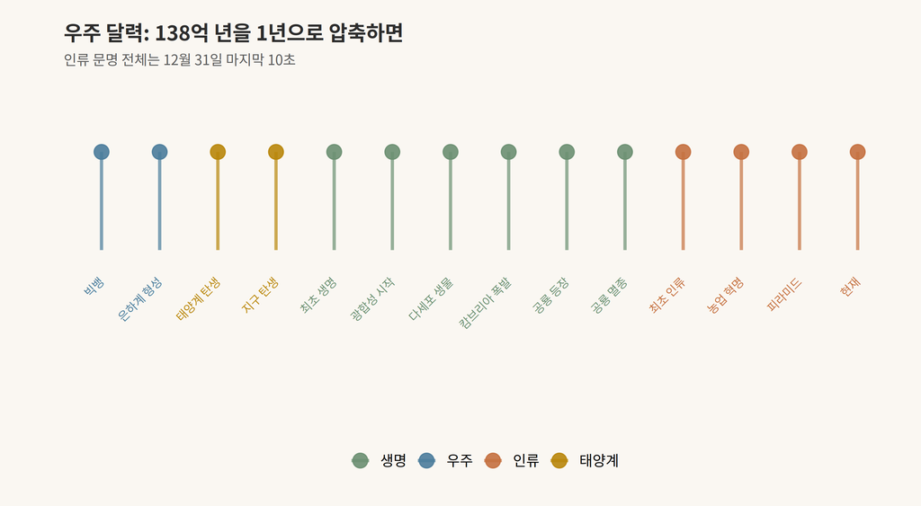

우주 달력 — 138억 년을 1년으로 압축하면

그리고 음악. 반겔리스의 〈Heaven and Hell〉 3악장이 오프닝 테마로 흐른다. 이 선율을 들어본 적 없다고 생각할 수도 있지만, 틀어놓으면 “아, 이거!” 하게 될 것이다. 과학 다큐멘터리에 그리스 전자음악 작곡가의 곡을 쓴다는 발상 자체가 이미 세이건다웠다.

[interactive chart not shown]

Spotify — Carl Sagan’s Cosmos Soundtrack

## 이 책이 실제로 하는 일

《코스모스》는 총 13장으로 구성되어 있다. 그런데 이 책은 ’교양 과학서’라는 분류가 잘 맞지 않는다. 읽어보면 안다. 이것은 과학서의 형식을 빌린, 문명 전체에 대한 에세이다.

1장 “코스모스의 바닷가에서”는 이렇게 시작한다. *“코스모스는 과거에 있었고, 현재에 있으며, 미래에도 있을 모든 것이다.”* 이것은 정의가 아니라 선언이다. 우주를 알겠다는 것이 아니라, 우주 안에서 자기 자리를 찾겠다는 선언.

책의 흐름을 따라가면 흥미로운 구조가 보인다:

- **1~3장**: 우주의 규모를 보여준다 (겸손의 시작)
- **4~6장**: 생명의 기원과 진화 (우연과 필연)
- **7~9장**: 고대 과학과 인류의 지적 모험 (이오니아의 유산)
- **10~11장**: 외계 생명의 가능성 (상상력의 확장)
- **12~13장**: 핵전쟁의 위험과 인류의 미래 (책임의 자각)

표면적으로는 우주 이야기인데, 읽다 보면 어느새 인간 이야기가 된다. 이것이 세이건의 설계다.

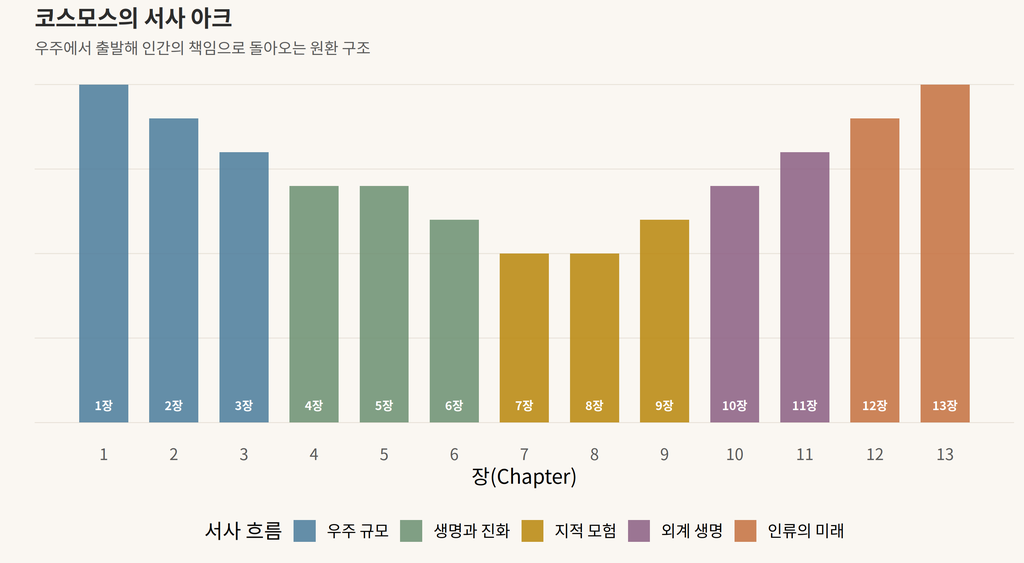

《코스모스》 13장의 구조 — 우주에서 시작해 인간으로 돌아온다

## 밀키웨이 안의 먼지 한 톨

이 책에서 가장 많이 인용되는 구절은 아마 이것일 것이다.

> *“우리는 코스모스가 스스로를 알기 위한 방법이다.”*

처음 읽으면 멋있는 말 같고, 두 번째 읽으면 좀 당혹스럽다. 우리가 코스모스의 ’방법’이라니. 그런데 세이건이 이 말을 할 때, 그는 시를 쓴 게 아니었다. 과학적 사실을 진술한 것이다.

우리 몸을 구성하는 탄소, 질소, 산소, 철 — 이것들은 수십억 년 전에 폭발한 별의 잔해다. 별 내부에서 수소가 헬륨으로, 헬륨이 탄소로, 탄소가 산소로 융합되고, 그 별이 초신성으로 폭발할 때 이 원소들이 우주 공간으로 흩어졌다. 그 먼지가 다시 모여 태양계가 되고, 지구가 되고, 결국 “왜?”라고 묻는 존재가 되었다.

별의 잔해가 별을 연구하고 있다. 이것은 비유가 아니다.

세이건은 이 사실을 “우리는 별의 재료로 만들어졌다 (We are made of star-stuff)”라는 문장으로 압축했다. 이 한 문장이 아마 20세기 과학 커뮤니케이션에서 가장 효과적인 문장일 것이다. 뉴턴 역학도, 양자역학도, 상대성이론도 이 정도로 사람의 가슴을 두드리지 못했다.

## 이오니아의 유산, 혹은 의심하는 법

《코스모스》의 7장은 고대 그리스의 이오니아 철학자들을 다룬다. 탈레스, 아낙시만드로스, 데모크리토스. 이 사람들이 왜 중요한가? 2600년 전에 이들은 세상을 신의 변덕이 아니라 자연 법칙으로 설명하려 했다. “번개가 치는 이유가 제우스의 분노가 아니라면, 뭔가 다른 이유가 있을 것이다.”

이것은 과학의 시작이 아니다. **의심의 시작**이다.

세이건이 이 장에서 진짜 하고 싶은 말은 고대 그리스 예찬이 아니다. 그 전통이 왜 끊어졌는가를 묻는 것이다. 알렉산드리아 도서관의 소실. 히파티아의 죽음. 지식이 권력에 의해 파괴되고, 의심이 이단으로 단죄되던 시대. 세이건은 이 대목에서 분명하게 경고한다 — 과학은 자연스러운 게 아니다. 의심할 수 있는 사회, 틀려도 되는 문화가 먼저 있어야 과학이 가능하다.

2026년에 이 경고를 읽으면, 소름이 돋는다. 가짜 뉴스, 반과학 운동, 기후 변화 부정론. 이오니아의 유산이 다시 위험해지고 있다.

## 1980년의 예언, 2026년의 현실

세이건은 《코스모스》에서 핵전쟁의 위험을 강하게 경고했다. 12장과 13장은 사실상 인류의 자기 파괴 가능성에 대한 호소다. “우리는 스스로를 파괴할 능력을 가진 최초의 종이다.” 1980년, 냉전이 절정이던 시기에 이 말은 당장의 공포였다.

핵전쟁은 (아직) 일어나지 않았다. 하지만 세이건의 경고는 형태를 바꿔서 여전히 유효하다. 기후 위기, AI의 통제 문제, 생물학적 무기. “스스로를 파괴할 능력”은 오히려 더 다양해졌다.

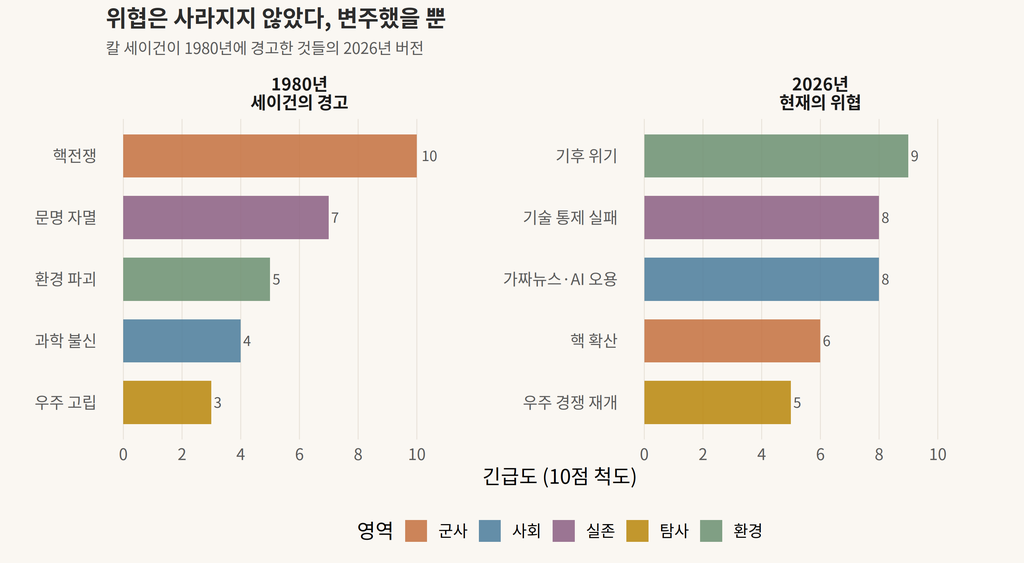

칼 세이건의 경고 — 1980년과 2026년 위협의 변주

## 세 권으로 읽는 칼 세이건

《코스모스》를 읽었다면, 이 사람이 남긴 지도를 좀 더 넓게 펼쳐볼 가치가 있다.

**《에덴의 용》(1977)** — 퓰리처상 수상작. 인간의 뇌가 어떻게 진화했는지를 추적한다. “파충류의 뇌” 위에 “포유류의 뇌”가 덧붙여지고, 그 위에 “신피질”이 올라탄 삼중 구조. 우리가 때때로 이성과 본능 사이에서 갈등하는 이유를 설명하는, 놀라울 정도로 솔직한 책.

**《창백한 푸른 점》(1994)** — 보이저 사진에서 시작된 후속작. 《코스모스》가 “우리는 어디서 왔는가”를 물었다면, 이 책은 “우리는 어디로 가야 하는가”를 묻는다. 2023년, 세이건이 직접 낭독한 오디오북이 미국 의회도서관 국가 녹음 등록부에 등재되었다. 죽은 사람의 목소리가 역사적 유산이 된 것이다.

**《코스모스 TV 시리즈》(1980)** — 책과 동시에 제작된 13부작 다큐멘터리. IMDB 평점 9.3. 반겔리스의 음악과 세이건의 내레이션이 어우러진, 교양 과학 다큐의 영원한 기준점.

[video not shown]

칼 세이건 — 우리는 별의 재료로 만들어졌다

## 0.07 픽셀의 교훈

어떤 책은 지식을 주고, 어떤 책은 시선을 바꾼다. 《코스모스》는 후자다.

이 책을 읽고 나면 밤하늘이 다르게 보인다. 별빛이 그저 반짝이는 점이 아니라, 수백만 년 전에 출발한 메시지처럼 느껴진다. 출퇴근길에 보는 노을이, 대기 중 질소와 산소 분자에 의해 산란된 태양 복사선이라는 사실이 시적으로 느껴진다. 이상한 일이다. 원리를 알면 신비가 줄어들어야 하는데, 세이건의 글을 읽으면 오히려 늘어난다.

그 비밀은 아마 겸손에 있다.

세이건은 지구가 우주의 중심이 아님을 증명한 모든 과학적 발견을 “위대한 격하”라고 불렀다. 코페르니쿠스가 지구를 중심에서 밀어냈고, 다윈이 인간을 창조의 정점에서 끌어내렸고, 허블이 우리 은하조차 특별하지 않음을 보여줬다. 격하의 연속. 그런데 세이건은 이것을 슬픈 이야기로 쓰지 않았다. 오히려 이렇게 말했다:

> *“우리가 얼마나 작은지를 안다는 것은, 우리가 얼마나 알고 있는지를 보여준다.”*

자신이 작다는 것을 아는 존재. 그것 자체가 경이로운 일이라는 역설. 《코스모스》의 진짜 주제는 우주가 아니다. 우주를 이해하려는 0.07 픽셀의 집념이다.

1996년 12월 20일, 칼 세이건은 골수이형성증으로 세상을 떠났다. 62세. 그가 마지막으로 남긴 책의 제목은 《악령이 출몰하는 세상 (The Demon-Haunted World)》이었다. 부제가 “어둠 속의 촛불로서의 과학”. 죽기 직전까지도 그는 같은 이야기를 하고 있었다 — 알려고 하는 태도 자체가 빛이라고.

창백한 푸른 점 위에서, 우리는 여전히 별을 올려다본다. 세이건이 남긴 가장 큰 유산은 지식이 아니라 시선이다. 고개를 들어 하늘을 보게 만드는 힘. 그리고 그 하늘을 보면서 “저것이 다 나의 이야기구나” 하고 느끼게 되는, 그 연결감.

오늘 밤, 하늘이 맑다면 잠깐 올려다보시길. 별 하나하나가 핵융합 반응로라는 사실을 떠올릴 필요는 없다. 그냥 올려다보는 것으로 충분하다. 칼 세이건이 원했던 것도 아마 그 정도였을 것이다.

Culture Voyager — 주말의 문화예술 매거진  
© 2026 Nakcho Choi · 목차로 돌아가기